# EDA - 2016 Presidential Campaign Contributions in Pennsylvania

# Introduction

This is an exploration of the political contributions made during the 2016 presidential race in Pennsylvania. This should provide an interesting look into one of the biggest surprises in the general election. It also happens to be my home state.

This exploratory data analysis will answer basic questions about the political contributions to campaigns in Pennsylvania. How much money was donated and to which candidates? In what quantities and in what frequency were people most likely to donate? From where in the state did the contributions come from? Which candidate and which political party got the most donations? And can we glean any insights into enthusiasm or participation levels?

Here’s the data source: http://fec.gov/disclosurep/pnational.do

To begin, we’ll look at the structure of the data.

```
'data.frame':   243796 obs. of  20 variables:
 $ cmte_id          : chr  "C00580100" "C00577130" "C00577130" "C00577130" ...
 $ cand_id          : Factor w/ 24 levels "P00003392","P20002671",..: 23 12 12 12 1 12 23 23 1 1 ...
 $ cand_nm          : Factor w/ 24 levels "Bush, Jeb","Carson, Benjamin S.",..: 22 19 19 19 4 19 22 22 4 4 ...
 $ contbr_nm        : Factor w/ 56881 levels " HOLMES, DONNA ANCYPA",..: 43133 29444 29444 29444 27659 26292 39067 39073 50701 4559 ...
 $ contbr_city      : Factor w/ 2090 levels "","17573-0318",..: 23 418 418 418 1435 1435 423 1574 1435 1253 ...
 $ contbr_st        : Factor w/ 1 level "PA": 1 1 1 1 1 1 1 1 1 1 ...
 $ contbr_zip       : chr  "18103" "19335" "19335" "19335" ...
 $ contbr_employer  : Factor w/ 17138 levels ""," JOHN L. SPIEGELMAN TYPE & TEXT",..: 7303 10590 10590 10590 10147 6022 7303 7303 10147 7303 ...
 $ contbr_occupation: Factor w/ 8496 levels ""," CERTIFIED REGISTERED NURSE ANESTHETIS",..: 3704 4884 4884 4884 6493 7756 3704 3704 6493 3704 ...
 $ contb_receipt_amt: num  75.3 15 10 10 21.6 ...
 $ contb_receipt_dt : Factor w/ 682 levels "01-APR-15","01-APR-16",..: 149 78 100 122 110 100 213 531 175 557 ...
 $ receipt_desc     : Factor w/ 30 levels "","* EARMARKED CONTRIBUTION: SEE BELOW REATTRIBUTION/REFUND PENDING",..: 1 1 1 1 1 1 1 1 1 1 ...
 $ memo_cd          : Factor w/ 2 levels "","X": 2 1 1 1 2 1 2 2 2 2 ...
 $ memo_text        : Factor w/ 123 levels "","*","* EARMARKED CONTRIBUTION: SEE BELOW",..: 1 3 3 3 12 3 1 1 12 12 ...
 $ form_tp          : Factor w/ 3 levels "SA17A","SA18",..: 2 1 1 1 2 1 2 2 2 2 ...
 $ file_num         : int  1146165 1077404 1077404 1077404 1091718 1077404 1146165 1146165 1091718 1091718 ...
 $ tran_id          : Factor w/ 243247 levels "A00232E849A8547D58D4",..: 160675 204212 204473 205165 83141 204265 157368 182949 83255 83804 ...
 $ election_tp      : Factor w/ 6 levels "","G2016","G2106",..: 2 5 5 5 5 5 2 2 5 5 ...
 $ party            : chr  "R" "D" "D" "D" ...
 $ contribution_date: Date, format: "2016-10-07" ...
```

We can possibly look at some of these other variables for some additional information, but with the amount of information, success seems doubtful. For example, consider contributor occupation. Perhaps there’s some insight into what these donors do, but at 8496 different values in the data, things don’t look too optimistic without some major categorizational effort.

There’s one major variable missing: party affiliation. This should be easy to deduce with some data wrangling. We’ll create a map of candidates to their party and add it to the data.

There are ~240K contributions total. Out of a state of ~13M, that doesn’t seem like a lot. Is that an indicator of low enthusiasm levels in general?

```
   cmte_id               cand_id
 Length:243796      P00003392:119288
 Class :character   P60007168: 59627
 Mode  :character   P80001571: 30828
                    P60006111: 15544
                    P60005915:  9800
                    P60006723:  3094
                    (Other)  :  5615
                      cand_nm                contbr_nm
 Clinton, Hillary Rodham  :119288   COMELLA, JOHN :   187
 Sanders, Bernard         : 59627   BETHEA, DAMON :   180
 Trump, Donald J.         : 30828   SHOVLIN, MARIE:   150
 Cruz, Rafael Edward 'Ted': 15544   ROSOFF, ANDREW:   142
 Carson, Benjamin S.      :  9800   SHORT, CHRIS  :   139
 Rubio, Marco             :  3094   LIBERTIN, MARY:   136
 (Other)                  :  5615   (Other)       :242862
       contbr_city     contbr_st     contbr_zip
 PHILADELPHIA: 32880   PA:243796   Min.   :        0
 PITTSBURGH  : 21740               1st Qu.:152322646
 WEST CHESTER:  3646               Median :180173915
 HARRISBURG  :  3638               Mean   :153092041
 LANCASTER   :  3620               3rd Qu.:190951323
 (Other)     :178271               Max.   :196125107
 NA's        :     1               NA's   :23
              contbr_employer               contbr_occupation
 N/A                  : 34161   RETIRED              : 56142
 RETIRED              : 31524   NOT EMPLOYED         : 17391
 SELF-EMPLOYED        : 16257   INFORMATION REQUESTED: 10269
 NONE                 : 12762   ATTORNEY             :  5928
 INFORMATION REQUESTED: 10342   PROFESSOR            :  5822
 (Other)              :138488   (Other)              :148175
 NA's                 :   262   NA's                 :    69
 contb_receipt_amt   contb_receipt_dt
 Min.   :-93308.0   12-JUL-16:  2512
 1st Qu.:    15.0   31-OCT-16:  2135
 Median :    27.0   29-FEB-16:  2102
 Mean   :   102.8   06-JUL-16:  2039
 3rd Qu.:    80.0   31-MAR-16:  2004
 Max.   : 10800.0   06-NOV-16:  1957
                    (Other)  :231047
```

[output cut: 9 more lines]

```
                                    :160839   SA17A:193065
 * EARMARKED CONTRIBUTION: SEE BELOW: 57902   SA18 : 49223
 * HILLARY VICTORY FUND             : 23233   SB28A:  1508
 *BEST EFFORTS UPDATE               :   335
 EARMARKED FROM MAKE DC LISTEN      :   281
 REDESIGNATION FROM PRIMARY         :   177
 (Other)                            :  1029
    file_num            tran_id       election_tp
 Min.   :1003942   C1014901 :     2        :   452
 1st Qu.:1077916   C10164585:     2   G2016: 92431
 Median :1104813   C10165181:     2   G2106:     1
 Mean   :1103468   C10179391:     2   O2016:    43
 3rd Qu.:1133832   C1022774 :     2   P2016:150868
 Max.   :1146285   C1022815 :     2   P2020:     1
                   (Other)  :243784
```

Here’s a bird’s eye view of the data. I’ll give some first impressions before getting to the plots. These are the main variables of interest.

1. cand_n, cand_id. First, the candidate ids match the candiate names exactly. This is good. It makes graphing this categorical variable easy. As for the data, Hillary Clinton got the most contributions by far, followed by Bernie Sanders. These two Democrats combined got ~6x as many contributions as the next candidate, Donald Trump, the Republican nominee. That’s a bit surprising given the outcome of the vote in the state. Maybe not as Pennsylvania has gone Democrat since 1988 and was considered a part of Clinton’s “blue wall”. Finally, going off this stat, Sanders had some real ground support in the state.
2. contributor name. I’m not an expert in campaign finance laws, but it looks like people can contribute multiple times. 187 times in fact as the most prolific contributor did. Contribution frequency seems like a possible candidate for measuring enthusiasm levels.
3. contributor city, zip. No surprise here. Philadelphia leads and Pittsburgh’s actually a pretty close second. The city and zip codes need cleaned up. I’ll probably do that for the zip codes. I’m going to venture a guess and say the cities make the most donations.
4. contributor employer and occupation. We find that one group leads the pack: retirees. That makes a lot of sense. Older people are more politically active. Also, what’s going on with so many unemployed people donating? Students? This data needs some cleaning, but hopefully we can gain some insights.
5. contribution date. I’d say there are probably two important periods in an election: the primaries and the general. Elections also contain critical moments, or crisis points. Perhaps a plot of contribution frequency by date could reveal peaks and valleys of contributions. Do supporters contribute more or less after a scandal or controversy? A look into when and how frequently people donated may give insights into levels of enthusiasm.
6. contribution amount. Nothing too surprising. It looks like there’s a few weird outliers, like a $93K refund and a $10k donation. Not sure what’s going on there. It looks like the vast majority of contributions were under $100. An analysis of contribution amount by candidate and party should yield interesting insights.

The rest of the variables contain minutiae that’s too technical for this cursory analysis. So we’ll ignore them.

Now onwards to the plots.

# Univariate Plots

First, here’s a histogram of the contribution frequency per candidate.

```
Ignoring unknown parameters: binwidth, bins, pad
```

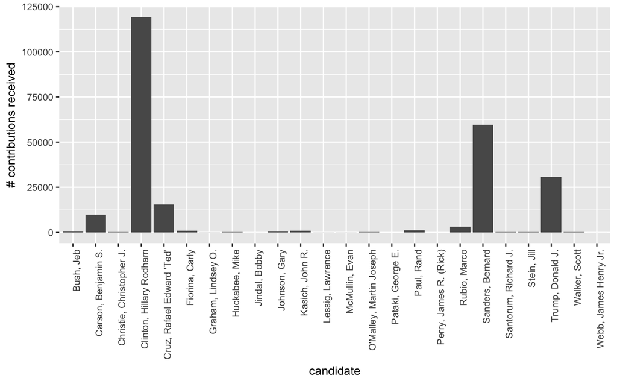

Next, we’ll look at the histogram the number of contributions by party. Right after we add a new variable: party.

There are 24 candidates who received contributions. 5 ran as Democrats, 3 as third party, and the rest Republican.

```
 [1] "Bush, Jeb"                 "Carson, Benjamin S."
 [3] "Christie, Christopher J."  "Clinton, Hillary Rodham"
 [5] "Cruz, Rafael Edward 'Ted'" "Fiorina, Carly"
 [7] "Graham, Lindsey O."        "Huckabee, Mike"
 [9] "Jindal, Bobby"             "Johnson, Gary"
[11] "Kasich, John R."           "Lessig, Lawrence"
[13] "McMullin, Evan"            "O'Malley, Martin Joseph"
[15] "Pataki, George E."         "Paul, Rand"
[17] "Perry, James R. (Rick)"    "Rubio, Marco"
[19] "Sanders, Bernard"          "Santorum, Richard J."
[21] "Stein, Jill"               "Trump, Donald J."
[23] "Walker, Scott"             "Webb, James Henry Jr."
```

```
Ignoring unknown parameters: binwidth, bins, pad
```

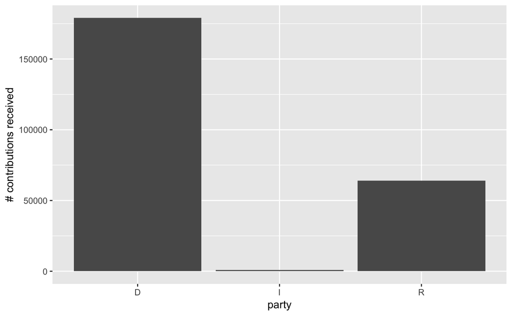

Lets look at a histogram of contribution frequency by donor, after some quick data aggregation on the contributor name.

```
[1] ROONEY, JEAN   LEONTOVICH, M  LEONTOVICH, M  LEONTOVICH, M
[5] KRAMER, VICKI  KERNS, MICHAEL
56881 Levels:  HOLMES, DONNA ANCYPA ... ZYLA, MICHAEL
```

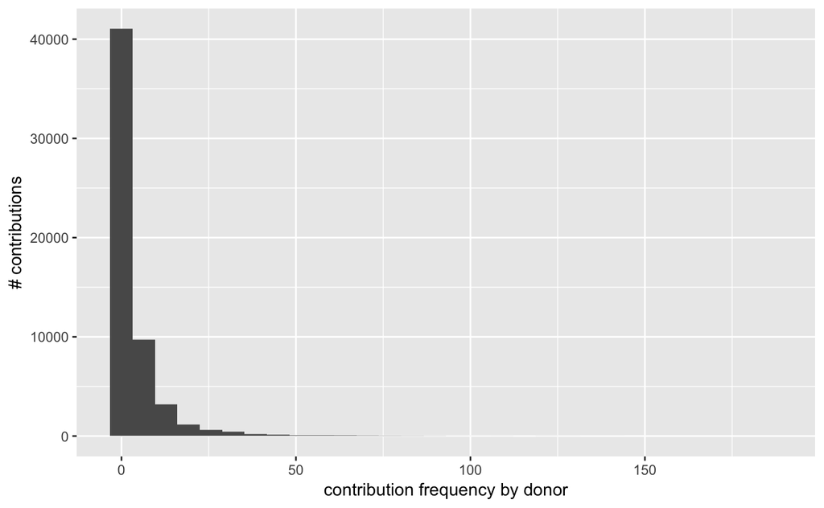

[output not shown]

This shows us that the vast majority of contributors only contributor a few times.

For contributes by zip code, first we’ll quickly cleanup the zip codes to be in the 5 digit format.

Contributions came from 1639 different zip codes in PA. There are 2174 total zip codes in the state. So ~500 zip codes did not contribute at all. Looking at the summary data, most zip codes did not have many contributions. Makes sense, I suppose. PA has some really rural areas.

```
  contbr_zip              n
 Length:1639        Min.   :   1.0
 Class :character   1st Qu.:   5.0
 Mode  :character   Median :  29.0
                    Mean   : 148.7
                    3rd Qu.: 123.0
                    Max.   :3806.0
```

The plot of the contribution by zip code reveals a very positively skewed histogram. Most contributions are concentrated in certain zip codes.

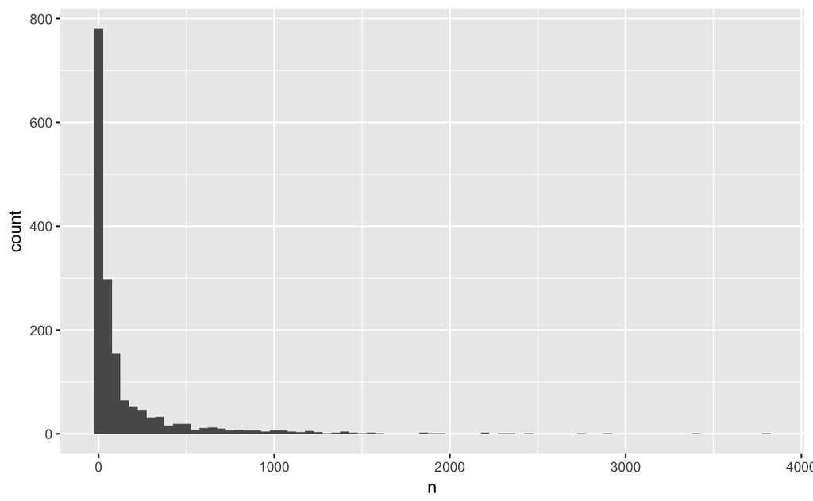

| contbr_zip | n |
| --- | --- |
| 19103 | 3806 |
| 19147 | 3409 |
| 15217 | 2897 |
| 19119 | 2756 |
| 19146 | 2461 |
| 19087 | 2326 |
| 19067 | 2307 |
| 19130 | 2192 |
| 19382 | 2181 |
| 15206 | 1939 |

[output cut: 15 more lines]

Now we’ll turn our attention to the contributor occupation and employer data. Again, I’ll do some data aggregation to get a count of each type.

Listing the top occupations, we see that that “RETIRED” leads the list, followed by “NOT EMPLOYED”. Further down we see some tradtional professional jobs like attorney, professor, physician, consultant, manager, teacher, etc. There are also a few different occupations that all fall under the umbrella of software. I wonder who they donated to.

| contbr_occupation | n |
| --- | --- |
| RETIRED | 56142 |
| NOT EMPLOYED | 17391 |
| INFORMATION REQUESTED | 10269 |
| ATTORNEY | 5928 |
| PROFESSOR | 5822 |
| PHYSICIAN | 5749 |
| TEACHER | 5400 |
| HOMEMAKER | 4005 |
| CONSULTANT | 2755 |
| MANAGER | 1872 |

[output cut: 15 more lines]

Retirees tower over all the rest.

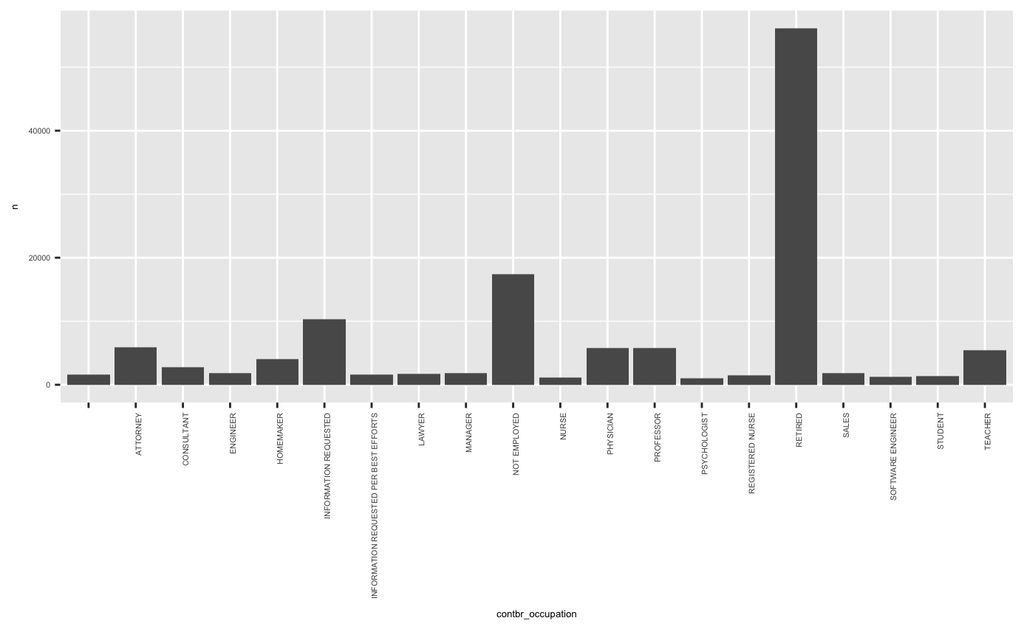

Moving on to look at contributions by date. Per usual, some data manipulation is needed. We’ll format the dates to make sorting and comparision easier.

Here were some important dates for the 2016 presidential election:

May 16 - PA Primaries

July 18 - Republican Convention

July 25 - Democratic Convention

September 26 - First Debate

October 9 - Second Debate

October 19 - Third Debate

November 7 - General Election

These are the official dates for important events. Other things obviously happened during the campaign. Maybe the data will point those out without us going out of our way to find them.

As for the data itself, the earliest contribution date is July 2014. That seems very early for the 2016 presidential race. These campaigns seem way too long. The median contribution date is June 2016, which makes sense as it’s right after the primaries and just before the convention.

```
        Min.      1st Qu.       Median         Mean      3rd Qu.
"2014-07-17" "2016-03-11" "2016-06-16" "2016-05-29" "2016-09-14"
        Max.
"2016-12-31"
```

This plot shows the frequency of contributions by date. We’ll use a bin width of 7 since that represents a week. Generally, contributions increased as the general election neared. There are a few notable peaks and valleys. Contributions peak right before primary, right after the conventions, and right before the general. Since this is all contributions, these are general trends. Below we’ll take a more in depth look on a per party and per candidate basis.

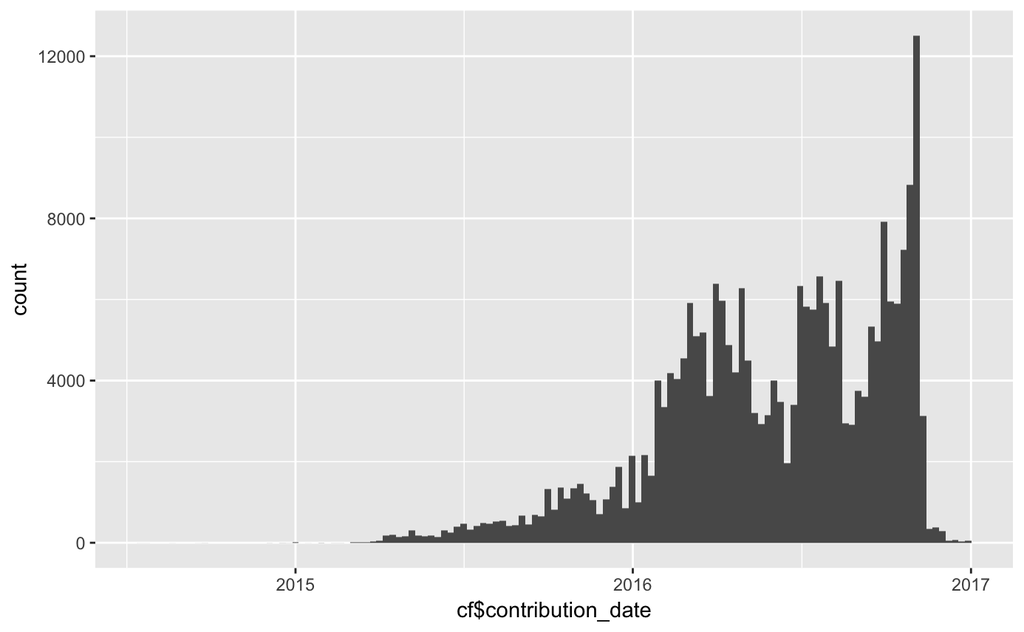

This plot shows the contribution frequency per date after the PA primary.

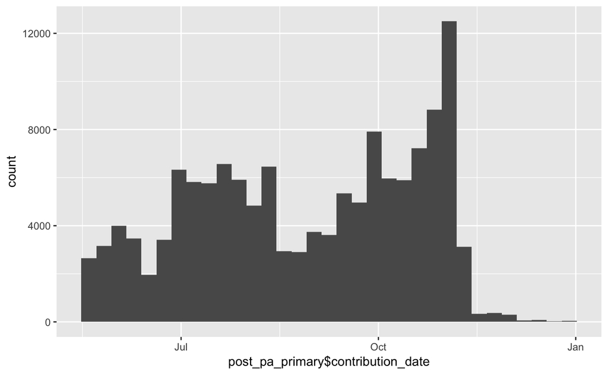

And just for fun, here’s the same plot for the period after the last debate.

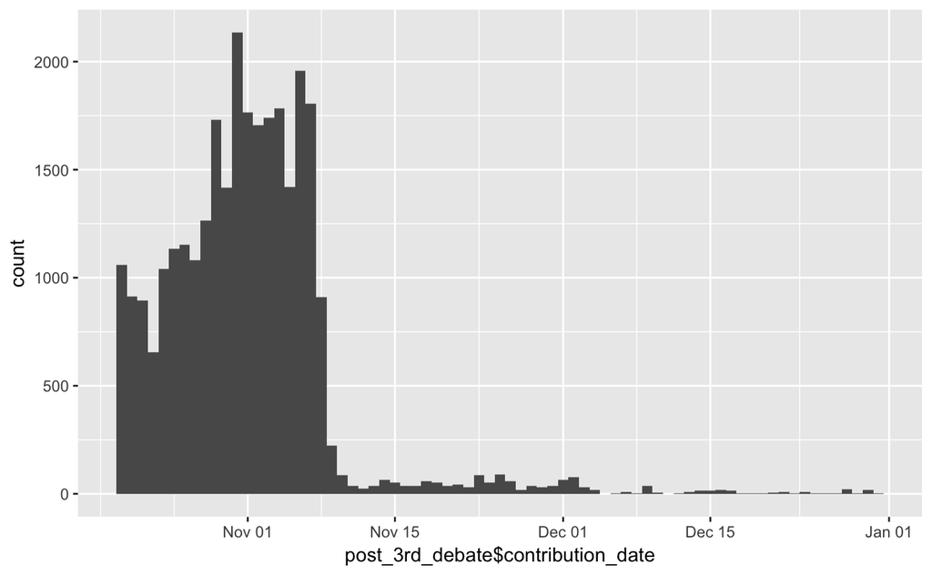

And finally, we switch to the amount per contribution. There are rules governing this and you can read about them here:

http://www.fec.gov/pages/brochures/citizens.shtml

```
    Min.  1st Qu.   Median     Mean  3rd Qu.     Max.
-93310.0     15.0     27.0    102.9     80.0  10800.0
```

First things first, there are some obvious outliers. Not sure what’s going on with a $93k refund, but I’m tempted to remove all refunds from the data. I’ll keep the $10k contribution.

With refunds removed, the summary statistics suggest that most contributions are small. The median is only $28. The mean’s a bit higher, but still only $109.

```
    Min.  1st Qu.   Median     Mean  3rd Qu.     Max.
    0.05    15.00    28.00   109.10    80.00 10800.00
```

Unsurprisingly, the plot’s very positively skwewed. There are lots and lots of small donations, and few big ones.

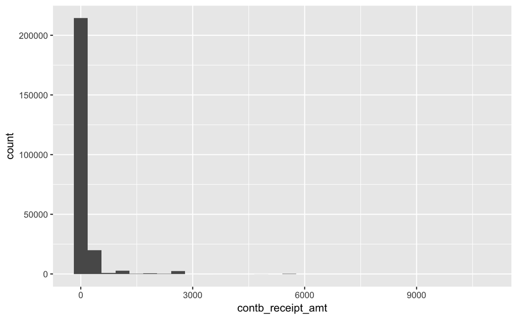

With these buckets, we see that most people make small donations. The $100-$1000 bucket stands out as a decent sized donation that a sizable amount of people made.

```
contribution_buckets
         (0,10]         (10,25]         (25,50]        (50,100]     (100,1e+03] (1e+03,2.7e+03] (2.7e+03,1e+04]
          47411           62255           60915           38062           28892            3342             148
```

```
[1] 10800
```

# Univariate Analysis

To summarize the above findings, most people contributed small amounts of money. Democrats overwhelmingly lead in political contributions received. And contributions followed a relatively predictable path in frequency based on the general milestones of an election.

I created one new variable: party. I also transformed the date variable into a “YYYY-MM-DD” format.

As for outliers, I decided to keep the big donations in the data set. Only 148 out of ~241k contributions were over $2700, i.e. the maximum amount allowed by an individual. Since the highest contribution amount is only $10,800. I do not think this has a big effect on the analysis of the data.

# Bivariate Plots

Now we’ll turn our attention to analysing relationships between the variables in our data. We’ll look at things like contribution amount and contribution frequency per candidate, per party, per zip code, and per occupation. Hopefully some interesting insights emerge in exploring these relationships.

Our first plot in this section will show the contributions raised by party. The Democrats raised $15,000,000 and the Republicans raised $10,000,000. This gap is a bit closer than the # of contributions graphed above, so it seems Republicans make bigger donations.

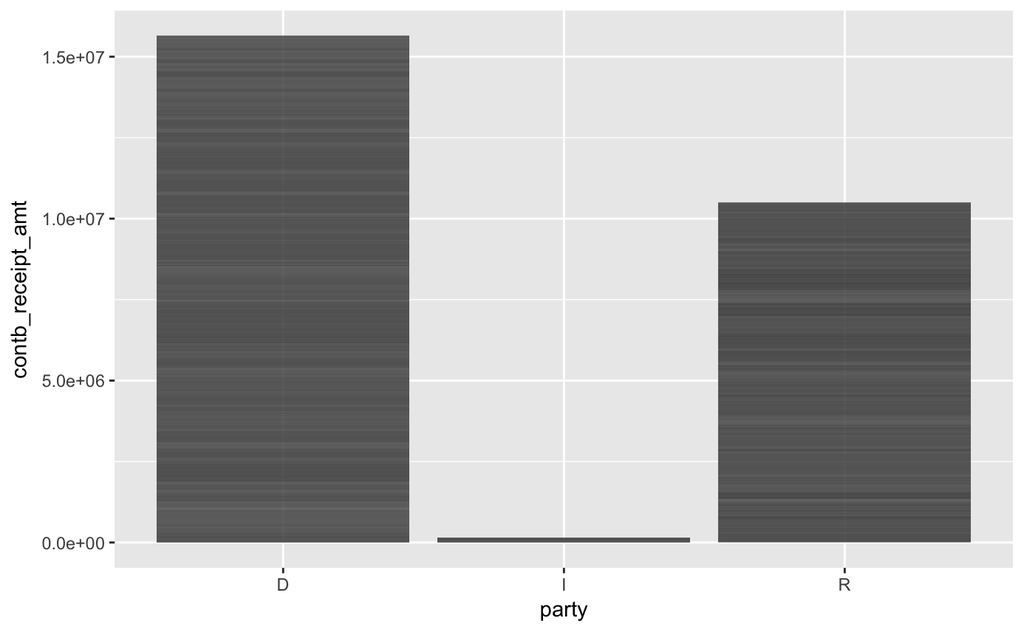

Next we’ll look at a boxplot of individual contributions. We’ll limit the contributions to between 0 and 2700, which is the upper limit for individuals per the rules. To make it readable, we’ll add a log10 scale for the y axis.

Nothing too surprising here. Republicans have higher donations in general. The third party candidates have the highest of the three.

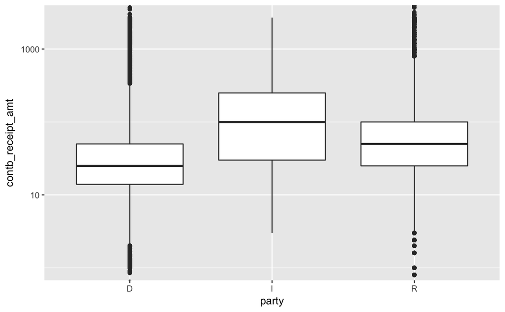

For amount raised by candidates, we’ll do some data aggregation first. And then plot the results.

The first plot will be the usual jumbled mess of 24 candidates, just to get a sense of things overall. The sorted table of total contribution amounts will shed light on which bars belong to which.

Clinton received the most money in contributions by far. She raised 3x as the next candidate, Trump. Sander did pretty well considering he only lasted till the primaries.

| cand_nm | sum |
| --- | --- |
| Clinton, Hillary Rodham | 12993199.10 |
| Trump, Donald J. | 4298152.19 |
| Sanders, Bernard | 2526100.67 |
| Cruz, Rafael Edward 'Ted' | 1548170.22 |
| Rubio, Marco | 1206813.76 |
| Carson, Benjamin S. | 921625.37 |
| Kasich, John R. | 644423.05 |
| Bush, Jeb | 479538.00 |
| Christie, Christopher J. | 436091.00 |
| Fiorina, Carly | 353288.27 |

[output cut: 14 more lines]

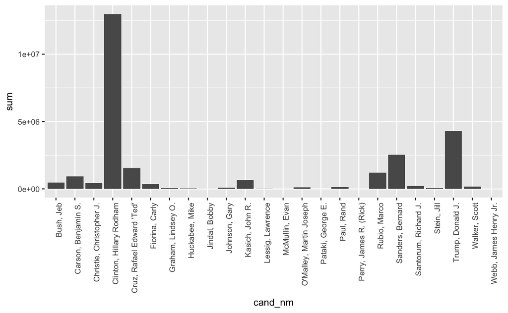

Next, we’ll look at the boxplots of the contributions amounts made to the top candidates. There will be three groups: general election candidates, primary candidate Democrats, and some primary candidate Republicans.

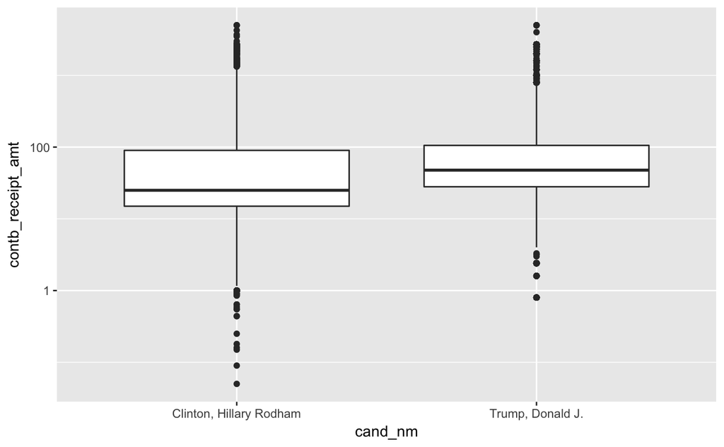

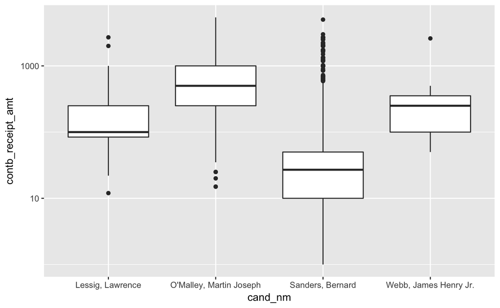

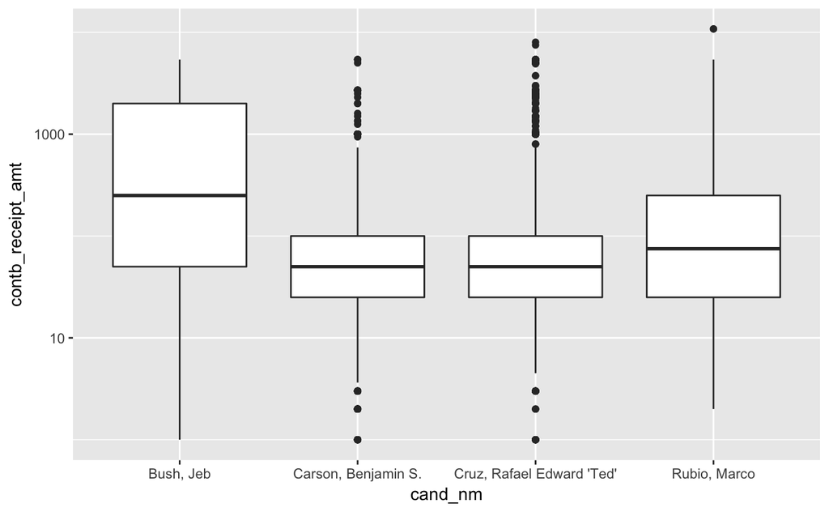

There are a few interesting takeaways from these boxplots. Keep in mind the y axis is log10 scaled.

For a “populist” candidate, Trump had less spread and higher mean contribution amounts than Clinton. He’s still a Republican it seems.

For the Democrats, Sanders had smaller contributions with a lot more variation. Lessig and O’Malley had more per contribution than some of the top Republicans. I don’t think they had much support, so maybe those that did probably tended to be more enthusiastic.

For the Republicans, Jeb had the support of those who make higher contributions. His mean contribution amount was ~$900. Compare that to Sander’s mean contribution amount: $27. Carson and Cruz had really similar amounts per contribution, which suggests that they share a base.

Here’s a better look at all of the candidates at once.

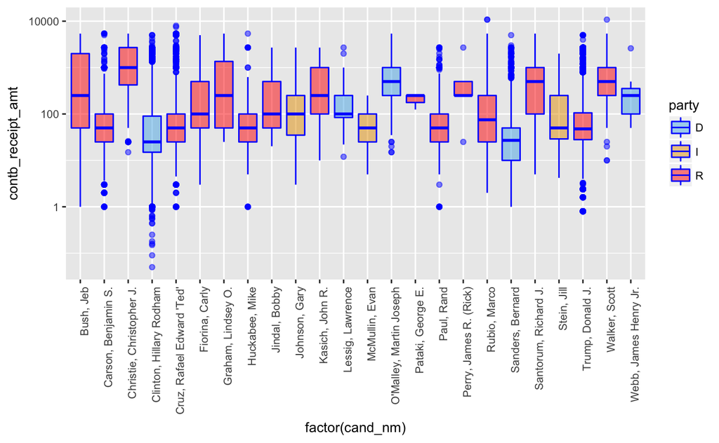

This next group of boxplots shows amount per contributions by occupation to each of the parties.

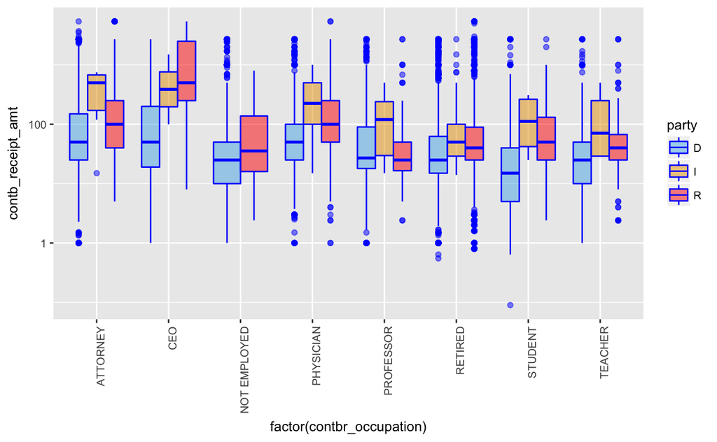

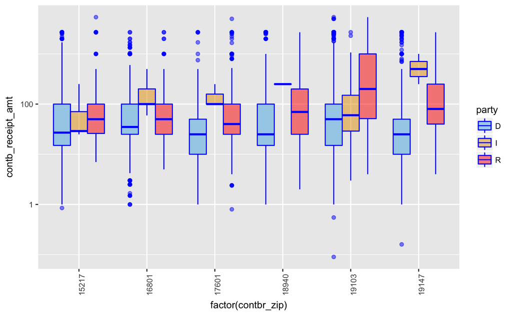

# Bivariate Analysis

In sum, Democrats raised more money than Republicans. Republicans in general had a higher mean $ amount per contribution. Ted Cruz and Ben Carson, two Republican nominees, had very similar spreads in terms of $ per contribution. This suggests they may have similar supporters, and thus share a base of support. One stark comparison was the mean and median $ amount per contribution between Democrat Bernie Sanders and Republican Jeb Bush. Jeb obviously had much bigger contributions from far fewer people. Chris Christie had the highest median contribution amount. And it seems like, in general, Republican contributors donated more per contribution than Democrats.

# Multivariate Plots

Next, we’ll switch to looking at contribution data per occupation. Above we saw that retirees, unemployed, and various professional careers made the most frequent contributions. Here we’ll hopefully see how much and to who they donated.

To accomplish this, we’ll first do some data wrangling to get two dataframes: contribution total amount by occupation and party, and contribution total amount by occupation and candidate.

There’s almost an endless amount of analysis we could do here. First, we’ll look at which occupations donated the most and for which party.

| contbr_occupation | party | total |
| --- | --- | --- |
| RETIRED | D | 2439064.62 |
| RETIRED | R | 2367054.43 |
| ATTORNEY | D | 1273801.13 |
| NOT EMPLOYED | D | 836555.49 |
| INFORMATION REQUESTED | R | 774802.85 |
| INFORMATION REQUESTED | D | 739960.39 |
| PHYSICIAN | D | 568499.16 |
| INFORMATION REQUESTED PER BEST EFFORTS | R | 531658.45 |
| PROFESSOR | D | 495807.68 |
| HOMEMAKER | R | 444081.63 |

[output cut: 40 more lines]

These are interesting. Retired folks donating to both parties lead the list. The unemployed donate a lot of money to Democrats. Attorneys, physicians, lawyers, consultants, and professors donating to Dems round out the top of the list. Not until you get down to the last 10 spots do you groups donating to Republicans: upper level management. Lastly, what’s up with Homemakers donating so much money to candidates? Seems like a good way to double up on donations.

Next, we’ll focus on the top two groups: the retired and the unemployed.

| contbr_occupation | party | total |
| --- | --- | --- |
| RETIRED | D | 2439064.6 |
| RETIRED | R | 2367054.4 |
| RETIRED | I | 17774.5 |

| contbr_occupation | cand_nm | total |
| --- | --- | --- |
| RETIRED | Clinton, Hillary Rodham | 2334353.12 |
| RETIRED | Trump, Donald J. | 1090649.27 |
| RETIRED | Cruz, Rafael Edward 'Ted' | 387150.11 |
| RETIRED | Carson, Benjamin S. | 381758.85 |
| RETIRED | Rubio, Marco | 192255.76 |
| RETIRED | Sanders, Bernard | 99961.50 |
| RETIRED | Kasich, John R. | 93283.25 |
| RETIRED | Bush, Jeb | 58923.00 |
| RETIRED | Fiorina, Carly | 50947.70 |
| RETIRED | Santorum, Richard J. | 33190.16 |

[output cut: 14 more lines]

I’m actually a bit surprised by the numbers for the contribution amounts for retired folk. By party, things are pretty much even. Clinton did much better than Trump, raising 2x as much, though. However, the Republican field had many more candidates, which diluted contributions. It’s interesting how much less money Sanders received from this group as well.

| contbr_occupation | cand_nm | total |
| --- | --- | --- |
| NOT EMPLOYED | Sanders, Bernard | 647725.74 |
| NOT EMPLOYED | Clinton, Hillary Rodham | 188379.75 |
| NOT EMPLOYED | Trump, Donald J. | 6818.53 |
| NOT EMPLOYED | Webb, James Henry Jr. | 450.00 |

Sanders crushed in contributions received from the unemployed. These may also be students (but maybe not as students have their own category).

Here’s a plot of the top professions with contributions amounts by party. Dems really rake in the contributions from these professional careers. It would be interesting to see if this is a national trend or something unique to Pennsylvania. I also added students because why not.

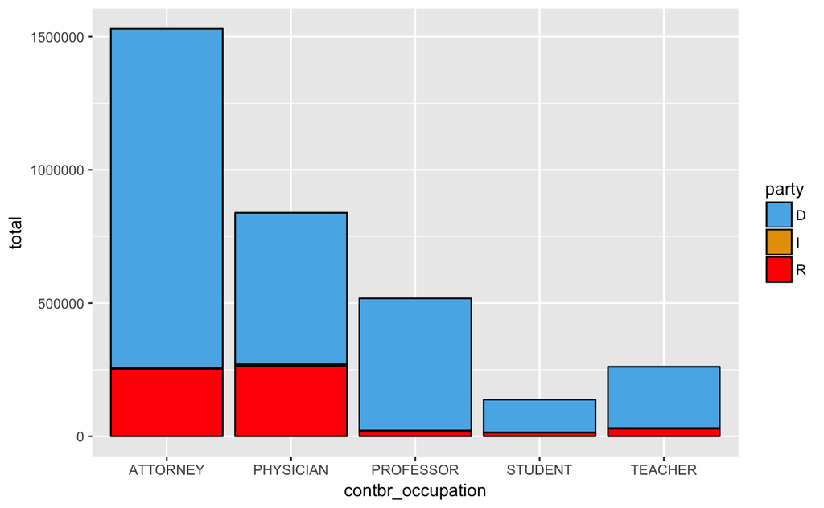

Next, lets take a look at donation frequency by date for the parties and candidates.

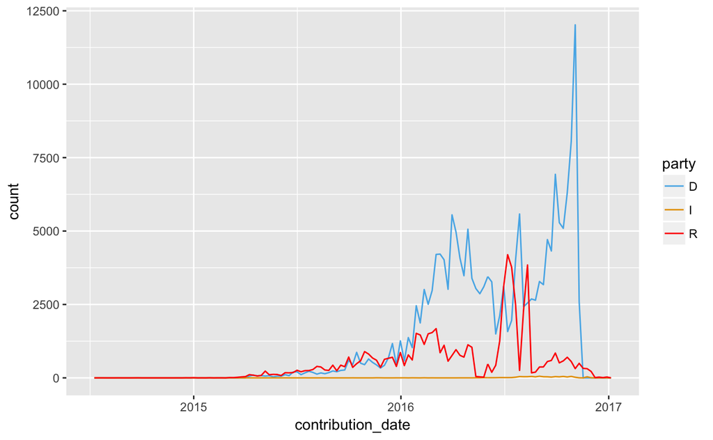

Wow. Republican donations really took a dive after the convention, whereas the Democrats kept going strong all the way to election night.

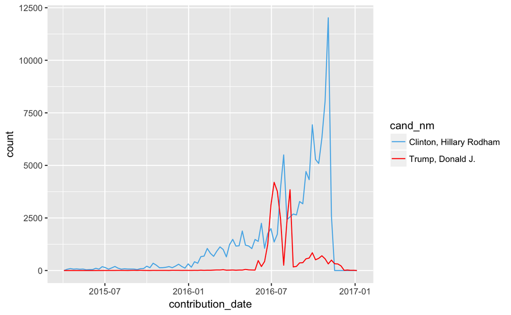

The same trend occurs when we limit things to just Clinton and Trump. Trump’s contributions really took a dip after the convention, whereas Clinton’s kept going strong all the way to the election.

What’s really striking is Trump barely has any activity until the Republican convention. Clinton has donations flowing in even during the primary.

# Multivariate Analysis

In sum, several things stood out. Retirees make the most donations to both parties as a group. And they donate equally to each party. The unemployed also donate a significant chunk of money, and mostly all of it goes to Democrats. Democrats get a lot more money from those in traditional professional careers, while Republicans get more money from business related professions. A frequency polygon of the number of contributions over time gives a good glimpse into enthusiasm. Democrats had the edge in that for the most part as well.

# Final Plots

## Plot 1 - Contribution frequency over the span of the election

I chose this plot because it seems like the best example of measuring enthusiasm. In my opinion, contribution frequency is a better measure of enthusiasm than contribution amount. This plot suggests that Clinton had an overwhelming amount of enthusiasm as she had the most contributions at basically every point. And these contributions seemed to keep flowing until the election. Trump’s contributions peaked right around the conventions and then plumetted. His contributions did extend past election day, however. Why people would contribute after the election is anyone’s guess. He had a few scandals and did not perform very well in the debates, so his declining contributions make sense. He really did not have much going for him in terms of contributions other than right around the conventions when his enthusiasm levels matched Clinton’s. It’s astonishing that he narrowly pulled out a victory in the state.

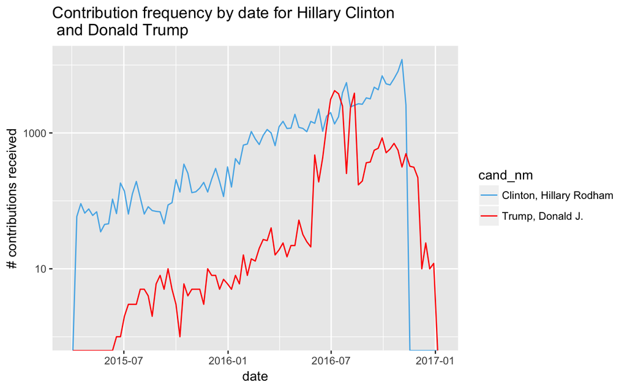

## Plot 2 - Donations per party by occupation

I found the donations by occupation really interesting. We trust these professionals to perform vital functions in our society, so it’s intersting to see who they support politically. It seems that the Democrats received a lot more money from these groups than Republicans.

As for retirees, it’s interesting to see just how much more money they contribute. Granted, there probably are a bunch more retirees than actively practicing attorneys or lawyers, and we’re not really sure which professions these retirees had in their working years. However, it is still interesting how much they give. What’s also striking is that they seem to donate an equal amount of money to Democrats and Republicans alike. This does suggest that retirees are more politically active than other sections of the population.

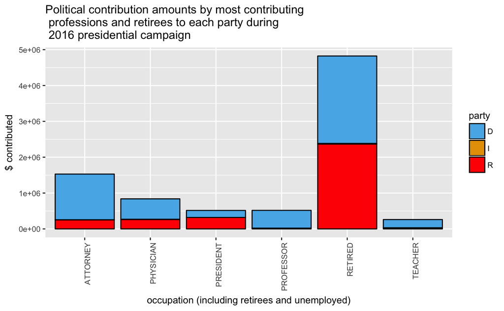

This is good stuff. If we accept this idea of contribution frequency as a measure of enthusiasm, then Pennsylvania seems to have felt the Bern until about the PA primary. Sanders leads in contribution frequency against Clinton until right around the PA primary. With that said, Clinton won the primary 56% - 44% (see https://en.wikipedia.org/wiki/Pennsylvania_Democratic_primary,_2016). That’s a solid win for her. About 1.6M people voted in the Democratic primary, and 2/3 of the ~240k donations went to Democrats. So maybe Benie only had the support of a dedicated minority. That raises an interesting question though. Who contributes to political campaigns and who actually votes?

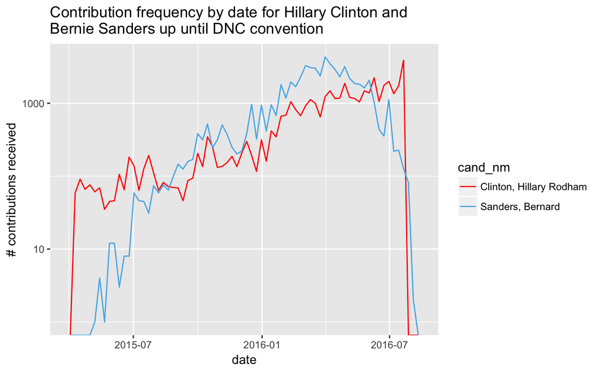

# Reflection

This data has only one quantative variable and a bunch of qualitative variables. So naturally most insights involve the amount of $ contributed to either candidates or parties by certain groups. The frequency of contributions from donors also produced a number of insights.

I made several decisions in working with the data. For most of the plots, I omitted negative contribution amounts, i.e. refunds. In some of the plots, I omitted donations outside the allowed individual of $2700. In some I didn’t.

I did a fair amount of data wrangling throughout the investigation. The dplyr package came in handy time and time again in aggregating data, e.g. aggregating contribution amounts by party and occupation. All of my plots used the ggplot2 package, as I’m most familiar with using it. These packages are fast and easy to use, so no difficulties in utilizing them. I also added one variable to the main data set: party. This made aggregating data by party easier. I also transformed the dates into a sortable format, i.e. (“YYYY-MM-DD”), which made things easier.

As for difficulties, I faced a few. First, the data is messy. Some of the variables, like contributor occupation and employer, are really messy. A more robust analysis may run into problems with other variables as well. Luckily this data set only had ~250k rows, which made it very manageable. I did run into some performance issues initially in plotting things. Some of the early plotting attempts took forever to produce, until I started aggregating data and plotting that. This decoupled the plotting with aggregating the data, speeding things up considerably. I learned that transforming data before plotting it is a smart way to do EDA.

I unfortunately did not get to analysing contributions from specific locations in the state. It must be possible to produce some sort of map, maybe a heatmap, of contributions by zip code. This would be a great visual of enthusiasm for either parties or candidates in various regions of the state. If I were to further this investigation, I would certainly add this.

I also did not do any sort of predictive modeling. Once I have more experience with this, I would definitely like to revisit this data and apply some models. It would be interesting to predict things like candidate choice based on contribution amount, zip code, or occupation. Political campaigns could use models like this to target certain voters for fundraising, or get out the vote efforts.

# Sources

http://www.datacarpentry.org/dc_zurich/R-ecology/04-dplyr.html

https://en.wikipedia.org/wiki/Pennsylvania_Democratic_primary,_2016

http://www.270towin.com/states/Pennsylvania

http://www.fec.gov/pages/brochures/citizens.shtml